# 对比模型1: 梯度提升树（Boosted Trees）

官方地址原文介绍：https://github.com/dmlc/xgboost

## 1. Boosted Trees简介

XGBoost，即“极端梯度提升”（Extreme Gradient Boosting），其中“梯度提升”一词源自Friedman的论文: $ Greedy\ \ Function\ \ Approximation:\ \ A\ \ Gradient\ \ Boosting\ \ Machine $。这是一种机器学习算法，它使用多棵决策树来提高模型预测的准确性，其主要思想是将多棵树组合起来，以提高模型整体的泛化能力和鲁棒性。

Boosted Trees是一种通用的集成学习算法，可以使用不同的损失函数和优化算法来实现。随机森林通过构建多个相互独立的决策树来形成一个强学习器，提升树通过逐步构建多个决策树，每棵新树尝试修正前一棵树的错误预测。

常见的Boosting算法有AdaBoost, Gradient Boosting, XGBoost等，它们都采用类似的策略，只是在细节和实现上有所不同。

## 2. Boosting的基本思想

Boosting算法的核心思想是通过迭代训练多个弱学习器（通常是决策树），每个弱学习器在前一个学习器的基础上进行改进，以减少模型的误差。Boosting的方法是加法模型，模型的最终预测是所有基学习器加权后得到的结果。

## 3. 目标函数和损失函数

Boosting方法通过最小化损失函数来优化模型的预测。设训练数据集为$ \{(x_i, y_i)\}$，其中$x_i$为协变量，$y_i$为响应变量。假设我们使用加法模型来构建预测函数，目标是最小化损失函数$L$。

一般来说，Boosting中的预测模型可以表示为：

$f(x) = \sum_{m=1}^M \alpha_m h_m(x)$

其中：

• $f(x)$ 是最终的预测结果。

• $h_m(x)$ 是第$m$个基学习器（通常是决策树）。

• $\alpha_m$ 是第$m$个基学习器的权重。

• $M$是基学习器的总数。

损失函数$L$衡量模型预测$f(x)$与真实值$y$之间的差异，常见的选择是平方误差（回归问题）：

$L(f) = \sum_{i=1}^N (y_i-f(x_i))^2$

## 4. 梯度提升（Gradient Boosting）

梯度提升（Gradient Boosting）通过逐步拟合当前模型的残差来改进模型。它的核心在于用梯度下降的方法来最小化损失函数。

### 4.1 初始化模型

首先，初始化模型$f_0(x)$为常数值，即所有样本的目标值的均值：

$f_0(x) = \frac{1}{N} \sum_{i=1}^{N} y_i$

此时，模型的损失函数为：

$L(f_0) = \sum_{i=1}^{N} \left( y_i - \frac{1}{N} \sum_{i=1}^{N} y_i \right)^2$

### 4.2 计算残差

在每一轮迭代中，计算当前模型的残差。残差$r_i$是目标值$y_i$与当前模型预测值之间的差异：

$r_i = y_i - f_{m-1}(x_i)$

### 4.3 拟合残差

训练一个新的基学习器$h_m(x)$，使其尽可能拟合残差。通常，我们使用一棵决策树来拟合残差。目标是最小化残差的平方误差：

$\min_{h_m} \sum_{i=1}^{N} (r_i - h_m(x_i))^2$

### 4.4 更新模型

新基学习器$h_m(x)$被加到当前模型中，通过加权更新模型。我们通过一个步长$\nu_m$来更新模型的参数：

$f_m(x) = f_{m-1}(x) + \nu_m h_m(x)$

其中，$\nu_m$是步长（学习率），控制每个新基学习器的贡献大小。通常，$\nu_m$会设定为小于1的常数，以避免过拟合。

### 4.5 梯度更新

通过梯度提升，更新的每一步实际上是沿着损失函数的负梯度方向进行的。假设损失函数是$L(f)$，我们通过计算梯度来更新模型：

$g_i^{(m)} = \frac{\partial L(f_{m-1})}{\partial f_{m-1}(x_i)}$

其中，$g_i^{(m)}$是损失函数在第$m-1$次迭代的模型上对第$i$个样本的梯度。基学习器$h_m(x)$被训练来拟合这个梯度，即最小化梯度的平方误差：

$h_m(x) = \arg \min_{h} \sum_{i=1}^{N} \left( g_i^{(m)} - h(x_i) \right)^2$

然后，更新模型：

$f_m(x) = f_{m-1}(x) + \nu_m h_m(x)$

### 4.6 损失函数的选择

Boosting算法的核心是通过不断优化损失函数来减少误差。不同的任务使用不同的损失函数。例如，在回归问题中，我们通常选择均方误差（MSE）作为损失函数：

$L(f) = \sum_{i=1}^{N} (y_i - f(x_i))^2$

而在分类问题中，常常使用对数损失函数（log loss）：

$L(f) = -\sum_{i=1}^{N} \left[ y_i \log(f(x_i)) + (1 - y_i) \log(1 - f(x_i)) \right]$

### 4.7 预测与模型的最终输出

经过$M$次迭代后，最终的预测模型为：

$f_M(x) = f_0(x) + \sum_{m=1}^{M} \nu_m h_m(x)$

这个模型是所有基学习器的加权和。

### 4.8 正则化与过拟合控制

在实际应用中，为了防止过拟合，通常对Boosting算法加入正则化项。正则化可以通过控制每个基学习器的复杂度（例如，限制树的深度）或者通过对每次迭代更新步长$\nu_m$进行控制来实现。

对于XGBoost等实现，正则化项通常包括L1（Lasso）和L2（Ridge）正则化：

这里，$\lambda$是正则化系数，控制模型复杂度。

## 5. Boosted Trees代码详解

```python
# 1. Boosted Trees (Gradient Boosting)
def BoostedTrees_train(X: np.ndarray, y: np.ndarray,
                      n_estimators: int = 1000,
                      max_depth: int = 300) -> GradientBoostingRegressor:
    """梯度提升树训练"""
    model = GradientBoostingRegressor(n_estimators=n_estimators,
                                     max_depth=max_depth,
                                     random_state=0)
    model.fit(X, y.ravel())
    return model
```

该函数使用了sklearn.ensemble模块中的GradientBoostingRegressor，这是一个用于回归任务的梯度提升模型。

### 5.1 GradientBoostingRegressor

$\textbf{GradientBoostingRegressor}$实现了梯度提升（Gradient Boosting）算法，逐步改进模型预测，通过在每次迭代中拟合残差（即模型误差）来构建一系列的基学习器（通常是决策树），并将它们加权求和生成最终的模型。

### 5.2 输入参数

• $\textbf{X}$ (特征矩阵)：这是一个二维数组，其中每行是一个样本，每列是一个特征。形状为 (n_samples, n_features)。

• $\textbf{y}$ (目标值)：这是一个一维数组，包含了对应样本的真实目标值（即回归问题中的连续值）。形状为 (n_samples,)。

• $\textbf{n_estimators}$：这是模型中基学习器（决策树）的数量。它决定了迭代的次数，也就是模型最终包含的树的数量。每棵树在训练时会修正前一棵树的误差。

• $\textbf{max_depth}$：每棵树的最大深度，控制树的复杂度。较深的树能够拟合更多的特征和非线性关系，但也容易过拟合。

### 5.3 GradientBoostingRegressor模型初始化

```python
model = GradientBoostingRegressor(n_estimators=n_estimators,
                                     max_depth=max_depth,
                                     random_state=0)
```

这行代码创建了一个GradientBoostingRegressor模型实例，并指定了以下参数：

• n_estimators：树的数量，表示希望模型使用多少棵树来构建最终的预测模型。

• max_depth：每棵树的最大深度，控制树的复杂度。较深的树能够拟合更多的特征和非线性关系，但也容易过拟合。代码中设置了300，表示每棵树最多深度为300，通常较大的深度可能会导致过拟合，因此需要根据数据进行调节。

• random_state=0：确保模型的可重复性，设置随机数种子，使每次运行的结果一致。

### 5.4 训练模型

```python
model.fit(X, y.ravel())
```

• $\textbf{fit}$方法用于训练模型。它会使用输入数据$X$和目标值$y$来训练模型。

• $\textbf{y.ravel()}$：ravel()方法将目标值$y$转换为一个扁平的数组。这通常是因为scikit-learn中的回归模型期望目标值是一个一维数组（即一列数据），即使输入数据$y$是二维的。

此行代码将模型拟合到给定的训练数据上。fit方法执行的操作可以分为几个步骤：

• 初始化模型：首先模型会初始化一个简单的预测（通常是所有输出的均值）。

• 训练每一棵树：通过计算残差（预测值与真实值的差）来训练每一棵树，每棵树都致力于修正之前树的误差。

• 更新模型：每棵树被训练后，它会被加到之前的模型中，所有树的加权和构成最终的模型。

• 迭代过程会根据n_estimators的值进行多次，直到达到指定的树的数量。

### 5.5 返回训练好的模型

```python
return model
```

训练完毕后，返回训练好的model，它是一个完整的Boosted Trees模型。可以使用它来对新数据进行预测。

# 对比模型2: 集成模型（Ensemble Model）

## 1. 集成模型简介

集成学习（Ensemble Learning）是一种将多个基学习器（或称弱学习器）组合起来，以提高整体预测能力的机器学习方法。集成方法通常能比单个模型更有效地减少误差，提高模型的准确性和泛化能力。

集成方法的核心思想是通过结合多个模型的预测结果，减少单个模型的偏差、方差或两者的影响。常见的集成方法有：

1. $\textbf{Bagging}$（Bootstrap Aggregating）：例如随机森林（Random Forest）。通过对训练集进行随机采样，训练多个模型，然后将其预测结果进行平均（回归问题）或投票（分类问题）。这种方法能够减少模型的方差，提高预测的稳定性。
2. $\textbf{Boosting}$：例如梯度提升树（Gradient Boosting）。通过迭代训练多个基学习器，每个学习器都在修正前一个学习器的错误，从而提高模型的预测精度。
3. $\textbf{Stacking}$：将多个模型的预测结果作为输入，训练一个最终的模型来进行预测。通常，每个基础模型独立训练，最后的组合模型负责做出最终决策。
4. $\textbf{Voting}$：通过简单的投票规则来结合多个模型的预测。常见的投票策略有：

• $\textbf{Hard Voting}$：根据每个模型的预测类别，通过投票决定最终类别。

• $\textbf{Soft Voting}$：对每个模型的输出概率进行加权平均，再选择概率最大的类别。

$\textbf{Stacking}$是一种集成学习方法，它通过将多个基学习器（如决策树、随机森林等）结合在一起，构建一个新的模型来进行预测。与传统的Bagging（例如随机森林）和Boosting（例如梯度提升树）不同，Stacking方法利用多个模型的预测结果作为输入，训练一个$\textbf{元学习器（meta-learner）}$来做最终的预测。

在Stacking中，模型的训练过程分为两个阶段：

1. $\textbf{基学习器训练阶段}$：多个基学习器（如决策树、随机森林等）分别在训练数据上进行训练，得到各自的预测结果。
2. $\textbf{元学习器训练阶段}$：基学习器的预测结果作为新特征输入到元学习器（例如线性回归），元学习器根据这些预测结果进行训练，并得出最终的预测结果。

Stacking的关键在于通过将多个模型的预测结果进行融合，能够充分利用每个基学习器的优点，通常能得到比单一模型更强大的预测能力。

Stacking模型的基本流程如下：

1. $\textbf{训练基学习器}$：

假设有$K$个基学习器，每个基学习器$h_i$都在训练数据集$\{X, y\}$上进行训练，得到对应的预测$\hat{y}_i$，其中$i = 1, 2, \dots, K$。

$\hat{y}_i = h_i(X)$

每个基学习器$h_i$得到的预测结果会成为下一步的输入特征。

2. $\textbf{训练元学习器}$：

将基学习器的预测结果组成一个新的数据集：

$Z = [\hat{y}_1, \hat{y}_2, \dots, \hat{y}_K]$

这里，$Z$是基学习器的预测结果，它作为输入特征传递给元学习器（通常是一个简单的模型，如线性回归），来学习最终的输出$\hat{y}$：

$\hat{y}_{\text{meta}} = \text{meta-learner}(Z)$

元学习器的目标是通过最小化损失函数，找到最优的权重（即每个基学习器的贡献），从而得到最终的预测结果。

## 2. 集成模型代码详解

```python
# 2. Ensemble Model (Stacking)
def Stacking_train(X: np.ndarray, y: np.ndarray,
                  base_models: list = None,
                  final_estimator = None) -> StackingRegressor:
    """Stacking集成模型训练"""
    if base_models is None:
        base_models = [
            ('dt3', DecisionTreeRegressor(max_depth=300)),
            ('dt5', DecisionTreeRegressor(max_depth=500)),
            ('rf', RandomForestRegressor(n_estimators=1000, max_depth=300))
        ]
    if final_estimator is None:
        final_estimator = LinearRegression()

    model = StackingRegressor(estimators=base_models,
                             final_estimator=final_estimator)
    model.fit(X, y.ravel())
    return model
```

### 2.1 基学习器（Base Models）

```python
if base_models is None:
    base_models = [
        ('dt3', DecisionTreeRegressor(max_depth=300)),
        ('dt5', DecisionTreeRegressor(max_depth=500)),
        ('rf', RandomForestRegressor(n_estimators=1000, max_depth=300))
    ]
```

• $\textbf{base_models}$：这是一个包含多个基学习器的列表。代码中，默认使用了三个基学习器：

• $\textbf{DecisionTreeRegressor(max_depth=300)}$：深度为300的决策树回归器。

• $\textbf{DecisionTreeRegressor(max_depth=500)}$：深度为500的决策树回归器。

• $\textbf{RandomForestRegressor(n_estimators=1000, max_depth=300)}$：1000棵树，深度为300的随机森林回归器。

这些基学习器的预测结果会作为元学习器的输入特征。

### 2.2 元学习器（Final Estimator）

```python
if final_estimator is None:
    final_estimator = LinearRegression()
```

• $\textbf{final_estimator}$：这是Stacking模型中的元学习器，它负责根据基学习器的预测结果做出最终的预测。在代码中，默认的元学习器是$\textbf{线性回归（LinearRegression）}$。

线性回归会根据基学习器的输出（即每个基学习器的预测结果）来学习如何组合这些输出，从而得到最终的预测。

### 2.3 创建StackingRegressor模型

```python
model = StackingRegressor(estimators=base_models, final_estimator=final_estimator)
```

### 2.4 训练Stacking模型

```python
model.fit(X, y.ravel())
```

• $\textbf{fit}$：使用训练数据$X$和目标值$y$来训练Stacking模型。

• 在训练过程中，每个基学习器会首先训练，并预测训练数据的结果。

• 接着，基学习器的预测结果会作为新的特征输入给元学习器，元学习器会根据这些特征进行训练，最终学习如何组合各个基学习器的输出，得到最终的预测结果。

### 2.5 返回训练好的模型

```python
return model
```

# 对比模型3: 多层感知机（MLP）

## 1. 多层感知机（MLP）简介

$\textbf{多层感知机（MLP, Multi-layer Perceptron）}$是一类前馈型人工神经网络，它由一个或多个隐藏层组成，每层通过激活函数进行非线性变换。MLP主要用于回归和分类任务，其网络结构包括输入层、隐藏层和输出层。

对于一个标准的MLP模型，给定输入向量$\mathbf{x} \in \mathbb{R}^n$，经过每层的线性变换和非线性激活后，最终输出$\hat{y}$（回归任务中的预测值）。

## 2. MLP结构详解

一个标准的单层MLP结构如下

### 2.1 输入层到隐藏层

假设输入向量为$\mathbf{x} = [x_1, x_2, \dots, x_n]$，隐藏层包含$h$个神经元。我们首先计算隐藏层的加权输入：

$\mathbf{z} = W^{(1)} \mathbf{x} + \mathbf{b}^{(1)}$

其中：

• $W^{(1)} \in \mathbb{R}^{h \times n}$是输入层到隐藏层的权重矩阵。

• $\mathbf{b}^{(1)} \in \mathbb{R}^h$是隐藏层的偏置向量。

• $\mathbf{z} \in \mathbb{R}^h$是隐藏层的输入。

### 2.2 应用激活函数

隐藏层的输出$\mathbf{a}^{(1)}$是加权输入经过激活函数$\sigma(\cdot)$的结果：

$\mathbf{a}^{(1)} = \sigma(\mathbf{z})$

这里的$\sigma$通常是非线性激活函数，比如$\textbf{ReLU、Sigmoid}$ 或$\textbf{tanh}$。对于回归任务，激活函数通常选用ReLU或tanh。

### 2.3 隐藏层到输出层

接着，隐藏层的输出$\mathbf{a}^{(1)}$进入输出层，计算输出层的加权输入：

$\hat{y} = W^{(2)} \mathbf{a}^{(1)} + \mathbf{b}^{(2)}$

其中：

• $W^{(2)} \in \mathbb{R}^{1 \times h}$是隐藏层到输出层的权重矩阵。

• $\mathbf{b}^{(2)} \in \mathbb{R}$是输出层的偏置项。

输出层的激活函数通常是线性的（对回归问题）。

### 2.4 MLP的损失函数和优化

对于回归问题，常用的损失函数是均方误差（MSE），它衡量了模型预测值与真实值之间的差异。均方误差的公式为：

$\mathcal{L}(\hat{y}, y) = \frac{1}{N} \sum_{i=1}^{N} \left( \hat{y}_i - y_i \right)^2$

其中：

• $N$是样本数。

• $\hat{y}_i$是第$i$个样本的预测值。

• $y_i$是第$i$个样本的真实值。

为了训练MLP，通常采用梯度下降法来优化损失函数，通过反向传播算法来计算梯度并更新权重和偏置。

## 3. MLP代码详解

```python
def MLP_train(X: np.ndarray, y: np.ndarray,
             hidden_size: int = 50,
             max_iter: int = 1000) -> MLPRegressor:
    """单层MLP训练"""
    model = MLPRegressor(hidden_layer_sizes=(hidden_size,),
                        max_iter=max_iter,
                        random_state=0)
    model.fit(X, y.ravel())
    return model
```

### 3.1 创建MLP模型

```python
model = MLPRegressor(hidden_layer_sizes=(hidden_size,),
                     max_iter=max_iter,
                     random_state=0)
```

• $\textbf{MLPRegressor}$是scikit-learn库中实现的多层感知机回归模型。

• $\textbf{hidden_layer_sizes}$：这个参数指定隐藏层的结构（即每个隐藏层的神经元数量）。如果 hidden_layer_sizes=(h,)，表示模型有一个隐藏层，且该隐藏层有$h$个神经元。

• $\textbf{max_iter}$：指定模型训练的最大迭代次数。它控制训练过程中的最大优化步骤数。如果优化在此之前收敛，训练会提前停止。

• $\textbf{random_state=0}$：随机数种子，确保每次训练的初始化是相同的，增加结果的可复现性。

### 3.2 模型训练

```python
model.fit(X, y.ravel())
```

这行代码通过调用fit方法来训练MLP模型：

• $\textbf{X}$是输入数据矩阵，其中每一行是一个样本，每一列是一个特征。

• $\textbf{y}$是目标值，表示每个样本的实际输出（回归任务中的连续值）。

fit方法内部会通过前向传播计算每层的输出，然后根据损失函数（如MSE）计算误差，再使用反向传播算法更新权重和偏置。优化过程通常采用随机梯度下降（SGD）或其他优化算法（如Adam）。

### 3.3 返回训练好的模型

```python
return model
```

最后，训练好的MLP（包含权重和偏置）会被返回。

### 3.4 多层感知机的优化和训练过程

MLP模型的训练过程包括以下几个步骤：

1. 前向传播：通过输入数据$\mathbf{X}$ ，逐层计算每一层的输出，直到得到最终的预测值$\hat{y}$ 。
2. 计算损失：计算模型预测值$\hat{y}$与实际目标值$y$之间的差异，通常通过MSE损失函数。
3. 反向传播：通过反向传播算法计算损失函数关于每个权重和偏置的梯度。
4. 更新权重：使用梯度下降或其他优化方法，根据计算得到的梯度来更新权重和偏置。
5. 迭代优化：这个过程会重复进行多次，直到达到最大迭代次数max_iter或者损失函数收敛。

# Note: 对于神经网络和MLP的知识点补充

http://cleverbobo.github.io/2020/08/30/bp/

## 背景介绍

神经网络灵感取自于生物上的神经元细胞，如下图所示

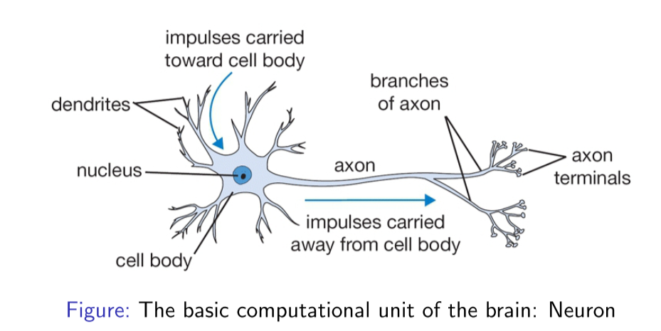

这是人体神经元的基本构成，其中树突主要用于接收其他神经元的信号，轴突用于输出该神经元的信号，数以万计的神经元相互合作，使得我们人类能够进行高级的思考，能够不断地对新事物进行学习。因此，我们就希望仿照人类神经网络的结构，搭建一种人为的神经网络结构，从而使其能够完成一些计算任务，这也是神经网络名字的由来。

## 节点结构

神经网络中计算的基本单元是神经元，一般称作“节点”（$node$）或者“单元”（$unit$）。每个节点可以从其他节点接收输入，或者从外部源接收输入，然后计算输出。每个输入都各自的“权重”（$weight$，即 $w$），用于调节该输入对输出影响的大小，节点的结构如图所示：

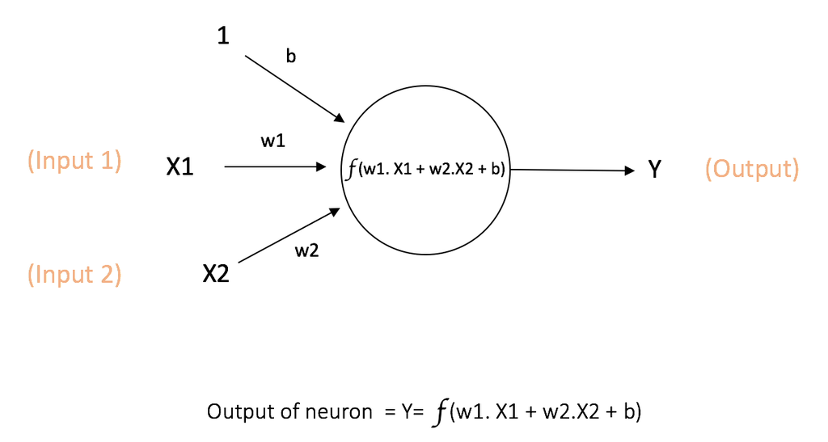

其中$x_1$,$x_2$作为该节点的输入，其权重分别为$w_1$和$w_2$。同时，还有配有“偏置$b$“（$bias$）的输入 ，偏置的主要功能是为每一个节点提供可训练的常量值（在节点接收的正常输入以外）。

神经元的输出$Y$按照上图中的计算方式进行，其中函数$f$叫做激活函数，一般采用非线性函数，其作用是将非线性引入神经元的输出。因为大多数现实世界的数据都是非线性的，我们希望神经元能够学习非线性的函数表示，如果激活函数仍然是线性的，那么根据线性可叠加的原理，整个函数模型仍然是线性的，那么就无法解决我们遇到的问题（例如异或），因此激活函数非线性这一点非常重要。

每个（非线性）激活函数都接收一个数字，并进行特定、固定的数学计算 。在实践中，可能会碰到几种激活函数：

1. $\textbf{Sigmoid}$（S型激活函数）：输入一个实值，输出一个$0$至$1$间的值$σ(x) = 1 / (1 + exp(−x))$
2. $\textbf{tanh}$（双曲正切函数）：输入一个实值，输出一个$[-1,1]$间的值$tanh(x) = 2σ(2x) − 1$
3. $\textbf{ReLU}$：ReLU代表修正线性单元。输出一个实值，并设定$0$的阈值（函数会将负值变为零$f(x) = max(0, x)$

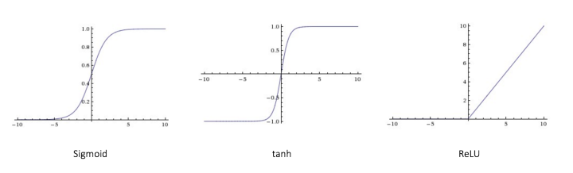

如图所示，该图为不同的激活函数的曲线图，第一种就是逻辑回归使用的激活函数，往往应用于二分类；在神经网络中，我们往往更倾向于使用最后一种relu函数作为激活函数。

## MLP结构

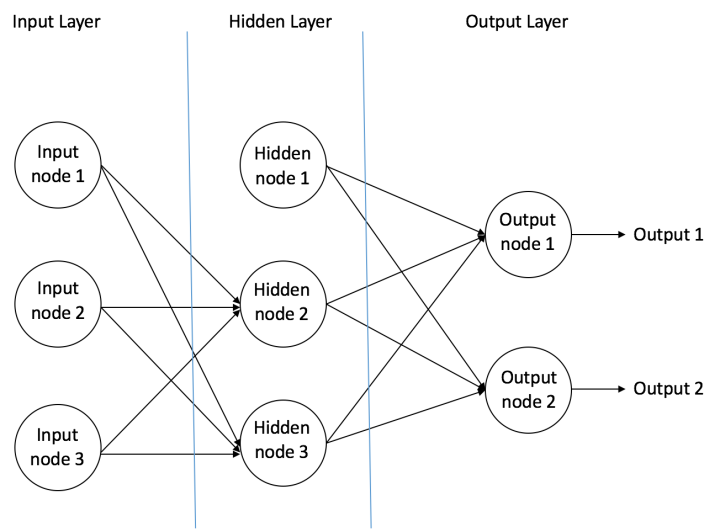

MLP的结构如图所示，主要由三部分组成，至少要有一个隐藏层。

1. $\textbf{输入节点}$（Input Nodes）：输入节点从外部世界提供信息，总称为"输入层"。在输入节点中，不进行任何的计算，仅向隐藏节点传递信息。
2. $\textbf{隐藏节点}$（Hidden Nodes）：隐藏节点和外部世界没有直接联系（由此得名）。这些节点进行计算，并将信息从输入节点传递到输出节点。隐藏节点总称为"隐藏层"。尽管一个前馈神经网络只有一个输入层和一个输出层，但网络里可以没有隐藏层（如果没有隐藏层，激活函数选择sigmod，那么就变成逻辑回归了），也可以有多个隐藏层。
3. $\textbf{输出节点}$（Output Nodes）：输出节点总称为"输出层"，负责计算，并从网络向外部世界传递信息。

## 数据前馈

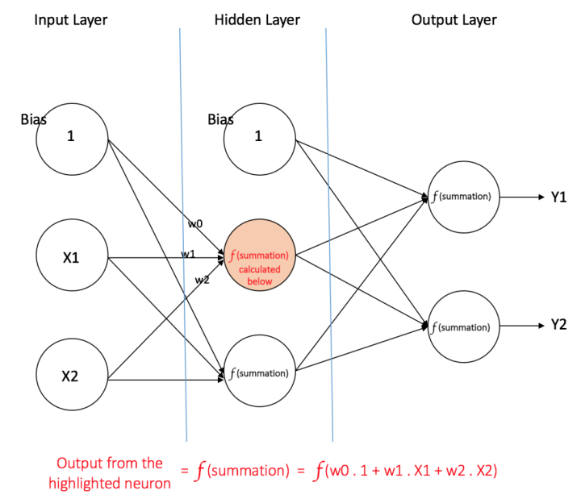

以之前的结构为例：

1. 输入层：输入层有三个节点。偏置节点值为1。其他两个节点，$X_1$和$X_2$取自外部输入（皆为根据输入数据集取的数字值）。和上文讨论的一样，在输入层不进行任何计算，所以输入层节点的输出是1、$X_1$和$X_2$三个值被传入隐藏层。
2. 隐藏层：隐藏层也有三个节点，偏置节点输出为1。隐藏层其他两个节点的输出取决于输入层的输出$（1，X_1，X_2）$以及连接上所附的权重。图中显示了隐藏层（高亮）中一个输出的计算方式。其他隐藏节点的输出计算同理。需留意$f$指代激活函数。这些输出会作为输出层的输入。
3. 输出层：输出层有两个节点，从隐藏层接收输入，并执行类似高亮出的隐藏层的计算。这些作为计算结果的计算值$（Y_1和Y_2）$就是多层感知器的输出。

给出一系列特征$X = (x_1, x_2, …)$和目标$Y$，一个多层感知器可以以分类或者回归为目的，学习到特征和目标之间的关系,从而建立模型。为了更好的理解多层感知器。

假设有这样一个学生分数数据集：

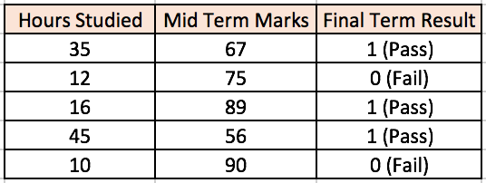

两个输入栏表示了学生学习的时间和期中考试的分数。最终结果栏可以有两种值：1或者0，来表示学生是否通过的期末考试。例如，我们可以看到，如果学生学习了35个小时并在期中获得了67分，他就会通过期末考试。现在我们假设我们想预测一个学习了25个小时并在期中考试中获得70分的学生是否能够通过期末考试。

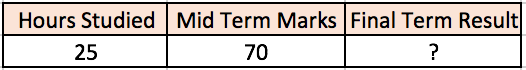

这是一个二元分类问题，首先，对网络中所有的权重进行随机分配，假设从输入连接到这些节点的权重分别为$w_1$、$w_2$和$w_3$（如图所示）。神经网络会将第一个训练样本作为输入，那么网络的输入=$[35, 67]$，涉及到的节点的输出$V$可以按如下方式计算（$f$是类似$Sigmoid$的激活函数）：$V = f(1×w_1 + 35×w_2 + 67×w_3）$，最后的得到我们的输出结果，假设输出层两个节点的输出概率分别为 0.4 和 0.6（因为权重随机，输出也会随机），但是我们期望的网络输出（目标）=$[1, 0]$，可以看出两者之间的差距还是蛮大的，那么该如何调整权重，使得输出的结果更加接近目标呢？

## 误差后馈

反向传播误差，通常缩写为“BackProp”，是几种训练人工神经网络的方法之一。这是一种监督学习方法，即通过标记的训练数据来学习（有监督者来引导学习）。简单说来，BackProp就像“从错误中学习”。监督者在人工神经网络犯错误时进行纠正。一个人工神经网络包含多层的节点: 输入层，隐藏层和输出层。相邻层节点的连接都有配有“权重”。学习的目的是为这些边缘分配正确的权重。通过输入向量，这些权重可以决定输出向量。在监督学习中，训练集是已标注的。这意味着对于一些给定的输入，我们知道期望的输出（标注）。

反向传播算法：最初，所有的边权重（edge weight）都是随机分配的。对于所有训练数据集中的输入，人工神经网络都被激活，并且观察其输出。这些输出会和我们已知的、期望的输出进行比较，误差会“传播”回上一层。该误差会被标注，权重也会被相应的“调整”。该流程重复，直到输出误差低于制定的标准。上述算法结束后，我们就得到了一个学习过的人工神经网络，该网络被认为是可以接受“新”输入的。该人工神经网络可以说从几个样本（标注数据）和其错误（误差传播）中得到了学习。

回到上面的学生分数数据集

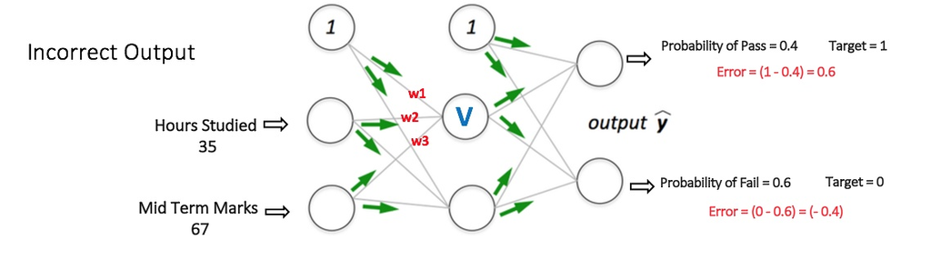

如图所示的多层感知器，其输入层有两个节点（除了偏置节点以外），两个节点分别接收“学习小时数”和“期中考试分数”。感知器也有一个包含两个节点的隐藏层（除了偏置节点以外）。输出层也有两个节点——上面一个节点输出“通过”的概率，下面一个节点输出“不通过”的概率。

在分类任务中，我们通常在感知器的输出层中使用$Softmax$函数作为激活函数，以保证输出的是概率并且相加等于 1。$Softmax$函数接收一个随机实值的分数向量，转化成多个介于0和1之间、并且总和为1的多个向量值。所以，在这个例子中：$Prob（Pass）+Prob（Fail）= 1$ 在上一小节，我主要介绍了数据的前向传播，那么下面来重点讲解误差反向传播和权重更新：计算输出节点的总误差，并将这些误差用反向传播算法传播回网络，以计算梯度。接下来，我们使用类似梯度下降之类的算法来调整网络中的所有权重，目的是减少输出层的误差。下图展示了这一过程（暂时忽略图中的数学等式）。

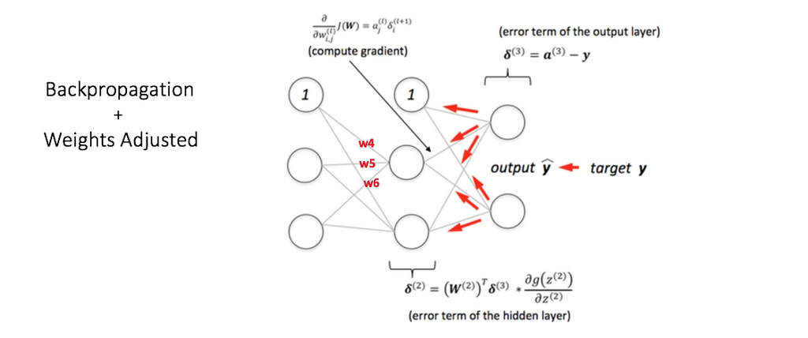

假设附给节点在反向传播和权重调整之后的新权重分别是$w_4$，$w_5$和$w_6$。接着用我们数据集中的其他训练样本来重复这一过程，不断迭代，这样，我们的网络就可以被视为学习了这些例子，从而使得输出误差不断减小，直到误差减小到一个合适的范围，那么我们就可以停止迭代了。这样我们就能够获得较为精准的预测模型。现在，如果我们想预测一个学习了25个小时、期中考试70分的学生是否能通过期末考试，我们可以通过前向传播步骤来计算Pass和Fail的输出概率。

## 过拟合和欠拟合

过拟合是指训练误差小，但是泛化误差较大；欠拟合是指训练误差大，泛化误差也很大。

神经网络相比于其他的机器学习算法，其功能更为强大，只要给予神经网络足够多的节点，理论上它就能拟合任意的模型，但是也有缺点，就是容易产生过拟合。那么产生过拟合的根本原因是什么呢？那是因为我们并不能保证训练样本完全正确，也就是可能存在部分的样本存在误导性，所以当神经网络功能过于强大时，很容易连训练样本中的错误样本也学习了，从而导致只能具有很低训练误差，而不能拥有较低的泛化误差，也就是我们所说的过拟合。最常见的方法之一是提前终止学习。

在合适的迭代次数终止算法从而达到最优容量（泛化误差最低），但是最佳迭代次数并不好找，往往需要多次测试才有可能找到，因此更常用的方法是“Dropout”防止过拟合。

## Dropout

Dropout可以作为训练深度神经网络的一种trick供选择。在每个训练批次中，通过忽略一半的特征检测器（让一半的隐层节点值为0），可以明显地减少过拟合现象。这种方式可以减少特征检测器（隐层节点）间的相互作用，检测器相互作用是指某些检测器依赖其他检测器才能发挥作用。

Dropout说的简单一点就是：我们在前向传播的时候，让某个神经元的激活值以一定的概率p停止工作，这样可以使模型泛化性更强，因为它不会太依赖某些局部的特征，如图所示。

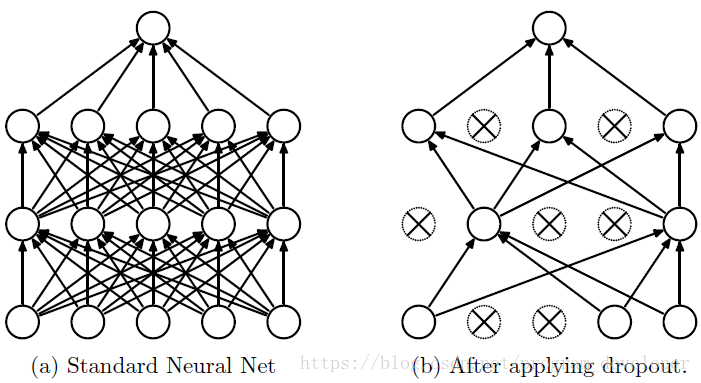

## Dropout工作流程及使用

假设我们要训练这样一个神经网络，如图所示。

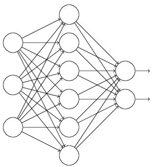

输入是$x$，输出是$y$，正常的流程是：我们首先把$x$通过网络前向传播，然后把误差反向传播以决定如何更新参数让网络进行学习。使用Dropout之后，过程变成如下：

1. 首先随机（临时）删掉网络中一半的隐藏神经元，输入输出神经元保持不变（图中虚线为部分临时被删除的神经元）

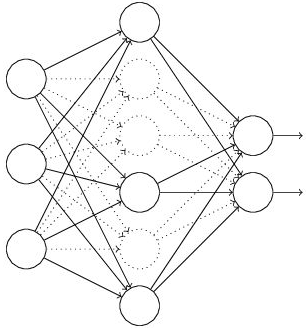

2. 然后把输入$x$通过修改后的网络前向传播，然后把得到的损失结果通过修改的网络反向传播。一小批训练样本执行完这个过程后，在没有被删除的神经元上按照随机梯度下降法更新对应的参数$（w，b）$。
3. 然后继续重复这一过程：

恢复被删掉的神经元（此时被删除的神经元保持原样，而没有被删除的神经元已经有所更新）

从隐藏层神经元中随机选择一个一半大小（这个量可以自己选）的子集临时删除掉（备份被删除神经元的参数）。

对一小批训练样本，先前向传播然后反向传播损失并根据随机梯度下降法更新参数$（w，b）$（没有被删除的那一部分参数得到更新，删除的神经元参数保持被删除前的结果）。

# 2025.02.26知识点补充：关于Stacking模型

Stacking是指训练一个模型用于组合其他各个模型。即首先训练出多个不同的模型，然后再以之前训练的各个模型的输出为输入来训练一个模型，以得到一个最终的输出。

如果可以选用任意一个组合算法，那么理论上，Stacking可以表示各种Ensemble方法。然而实际中，通常使用单层的logistic回归作为组合模型。

$\textbf{注意}$：Stacking有两层，一层是不同的基学习器，第二个是用于组合基学习器的元学习器。

$\textbf{Stacking的基本步骤如下：}$

1. 数据集划分：将训练数据集划分为多个子集，通常是两个或多个。这些子集可以按照不同的方式划分，例如随机划分或使用交叉验证。
2. 基础模型训练和预测：对于每个子集，使用不同的基础模型进行训练和预测，得到每个基础模型的预测结果。这些基础模型可以是任何机器学习算法，如决策树、支持向量机、神经网络等。
3. 特征组合：将这些预测结果作为新的特征，组成一个新的训练数据集。这些预测结果可以作为原始特征等补充，提供更多的信息来训练元模型。
4. 元模型训练：使用这个新的训练数据集来训练一个元模型，元模型可以是任何机器学习算法，例如逻辑回归、决策树等，元模型的目标是学习如何结合基础模型的预测结果，以最大化整体模型的准确性。
5. 预测：最后，使用训练好的元模型来对测试数据进行预测。元模型会根据基础模型的预测结果进行组合加权，生成最终的预测结果。

通过Stacking，基础模型的不同特点和优势可以得到充分的发挥，从而提高整体模型的性能。然而，Stacking也需要谨慎使用，因为它可能会增加模型的复杂性和计算成本，并且在数据集较小或不平衡的情况下可能会导致过拟合的问题。因此，在应用Stacking时需要进行适当的调参和验证，以确保获得最佳的性能和泛化能力。

## Stacking原理讲解

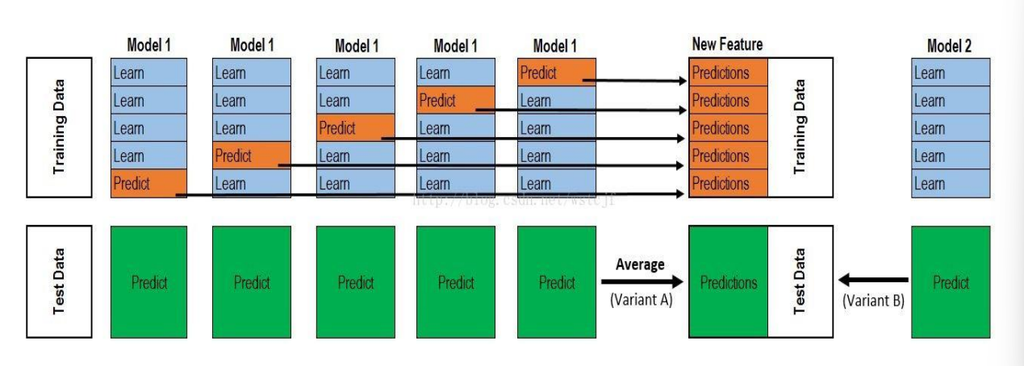

图中上半部分是用一个基础模型进行5折交叉验证，如：用XGBoost作为基础模型Model1，5折交叉验证就是先拿出四折作为training learn（蓝色部分），另外一折作为testing predict（橙色部分）。注意：在stacking中此部分数据会用到整个training data。如：假设我们整个training data包含10000行数据，testing data包含2500行数据，那么每一次交叉验证其实就是对training data进行划分，在每一次交叉验证中的training learning将会是8000行，testing predict是2000行。

在完成对Model1的整个步骤之后，我们可以发现$a_1$，$a_2$，$a_3$，$a_4$，$a_5$其实就是对原来整个training data的预测值，将它们按列拉直，会形成一个10000行一列的矩阵，记为$A_1$，而对于$b_1$，$b_2$，$b_3$，$b_4$，$b_5$这部分数据，我们将个部分相加取平均值，得到一个2500行一列的矩阵，记为$B_1$。

以上就是Stacking中一个模型的完整流程。Stacking中同一层通常包含多个模型，假设还有$Model2: LR$、$Model3: RF$、$Model4: GBDT$、$Model5: SVM$，对于这四个模型，我们可以重复以上的步骤，在整个流程结束之后，我们可以得到新的$A_2$、$A_3$、$A_4$、$A_5$，以及$B_2$、$B_3$、$B_4$、$B_5$矩阵。

在此之后，我们把$A_1$、$A_2$、$A_3$、$A_4$、$A_5$并列合并，得到一个10000行5列的矩阵，作为新的training data，$B_1$、$B_2$、$B_3$、$B_4$、$B_5$并列合并，得到一个2500行5列的矩阵作为新的testing data。让下一层的模型（元学习器）基于它们进一步训练。

Stacking是一种集成学习方法，通过将多个基础模型的预测结果结合起来，以提高整体预测的准确性。